# Simple Regression with brms (Exercise)

Vedant Shah 987144

04/20/2020

```r
# package for convenience functions (e.g. ggplot2, dplyr, etc.)
library(tidyverse)
# package for Bayesian regression modeling
library(brms)
# package for visualization
library(tidybayes)

# package to visualize
library(bayesplot)
# these options help Stan run faster
options(mc.cores = parallel::detectCores())

#devtools::install_github("michael-franke/aida-package")
library(aida)

# and our dataset, let's call it dolphin
dolphin <- aida::aidata

# use the aida-theme for plotting
theme_set(theme_aida())

# global color scheme / non-optimized
project_colors = c("#E69F00", "#56B4E9", "#009E73", "#F0E442", "#0072B2", "#D55E00", "#CC79A7", "#000000")

# setting theme colors globally
scale_colour_discrete <- function(...) {
  scale_colour_manual(..., values = project_colors)
}
scale_fill_discrete <- function(...) {
   scale_fill_manual(..., values = project_colors)
}
```

## Exercise 2

1. Create a new dataframe that contains only the mean values of the RT, and MAD for each animal (`exemplar`) and for correct and incorrect responses. Print out the `head` of the new dataframe.

```r
df <- dolphin %>% group_by(exemplar, correct) %>% summarise(RT = mean(RT), MAD = mean(MAD))
head(df)
```

```
## # A tibble: 6 x 4
## # Groups:   exemplar [3]
##   exemplar  correct    RT   MAD
##   <chr>       <dbl> <dbl> <dbl>
## 1 alligator       0 4246. 271.
## 2 alligator       1 1717.  87.4
## 3 bat             0 3334. 176.
## 4 bat             1 2252. 182.
## 5 butterfly       0 1636.  15.0
## 6 butterfly       1 1761. 145.
```

2. Run a linear regression using brms. `MAD` is the dependent variable (i.e. the measure) and both `RT` and `correct` are independent variables (`MAD ~ RT + correct`). Tip: the coefficients might be really really small, so make sure the output is printed with enought numbers after the comma.

```r
# specify the model
model1 <- brm(
  # model formula
  MAD ~ RT + correct,
  data = df
  )


summary(model1)
```

```
##  Family: gaussian
##   Links: mu = identity; sigma = identity
## Formula: MAD ~ RT + correct
##    Data: df (Number of observations: 36)
## Samples: 4 chains, each with iter = 2000; warmup = 1000; thin = 1;
##          total post-warmup samples = 4000
##
## Population-Level Effects:
##           Estimate Est.Error l-95% CI u-95% CI Rhat Bulk_ESS Tail_ESS
## Intercept    20.49     35.85   -49.35    91.20 1.00     4355     2476
## RT            0.06      0.02     0.03     0.09 1.00     4414     3314
## correct     -14.40     26.54   -67.77    38.65 1.00     4182     2602
##
## Family Specific Parameters:
##       Estimate Est.Error l-95% CI u-95% CI Rhat Bulk_ESS Tail_ESS
## sigma    77.60      9.75    61.38    99.18 1.00     3318     2542
##
## Samples were drawn using sampling(NUTS). For each parameter, Bulk_ESS
## and Tail_ESS are effective sample size measures, and Rhat is the potential
## scale reduction factor on split chains (at convergence, Rhat = 1).
```

Try to understand the coefficient table. There is one coefficient for `RT` and one coefficient for `correct` which gives you the change in MAD from incorrect to correct responses.

3. Plot a scatter plot of MAD ~ RT and color code it for correct responses (Tip: Make sure that `correct` is treated as a factor and not a numeric vector). Draw two predicted lines into the scatterplot. One for correct responses (“lightblue”) and one for incorrect responses (“orange”).

[output not shown]

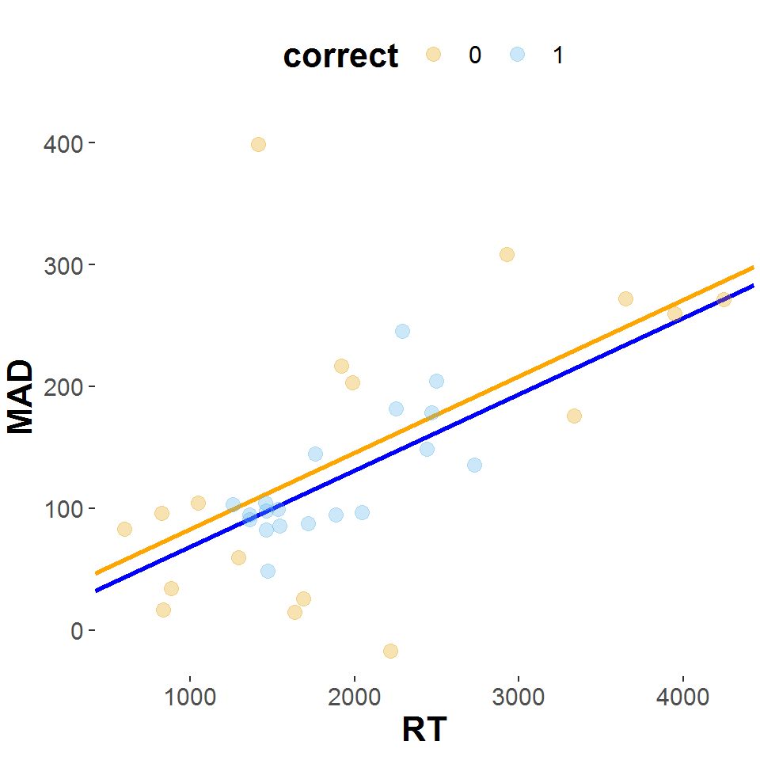

```r
# extract model parameters:
model_intercept <- summary(model1)$fixed[1]
model_slope <- summary(model1)$fixed[2]
model_correct <- summary(model1)$fixed[3]


# plot
df %>% mutate(correct = as.factor(correct)) %>%
ggplot(aes(x = RT,
           y = MAD, color = correct)) +
  geom_abline(intercept = model_intercept+model_correct, slope = model_slope, color = "blue", size  = 1) +
  geom_abline(intercept = model_intercept, slope = model_slope, color = "orange", size  = 1) +
  geom_point(size = 3, alpha= 0.3) +
  theme_aida()
```

4. Extract the posteriors for the coefficients of both `RT` and `correct` from the model output (use the `spread_draws()` function), calculate their means and a 67% Credible Interval. Print out the `head` of the aggregated dataframe.

```r
posteriors1 <- model1 %>%
  spread_draws(b_RT, b_correct) %>%
  select(b_RT, b_correct)



summarize_sample_vector <- function(samples, name = '') {
    tibble(
      Parameter = name,
      '|67%' = HDInterval::hdi(samples, credMass = 0.67)[1],
      mean  = mean(samples),
      '67%|' = HDInterval::hdi(samples, credMass = 0.67)[2]
    )
}

rbind(
  summarize_sample_vector(posteriors1$b_RT, "RT"),
  summarize_sample_vector(posteriors1$b_correct, "Correct")
)
```

```
## # A tibble: 2 x 4
##   Parameter   `|67%`     mean `67%|`
##   <chr>        <dbl>    <dbl>  <dbl>
## 1 RT          0.0492   0.0626 0.0784
## 2 Correct   -40.3    -14.4    9.28
```

5. BONUS I : Plot the scatterplot from 2c and plot 50 sample tuples for the regression lines for correct and incorrect responses.

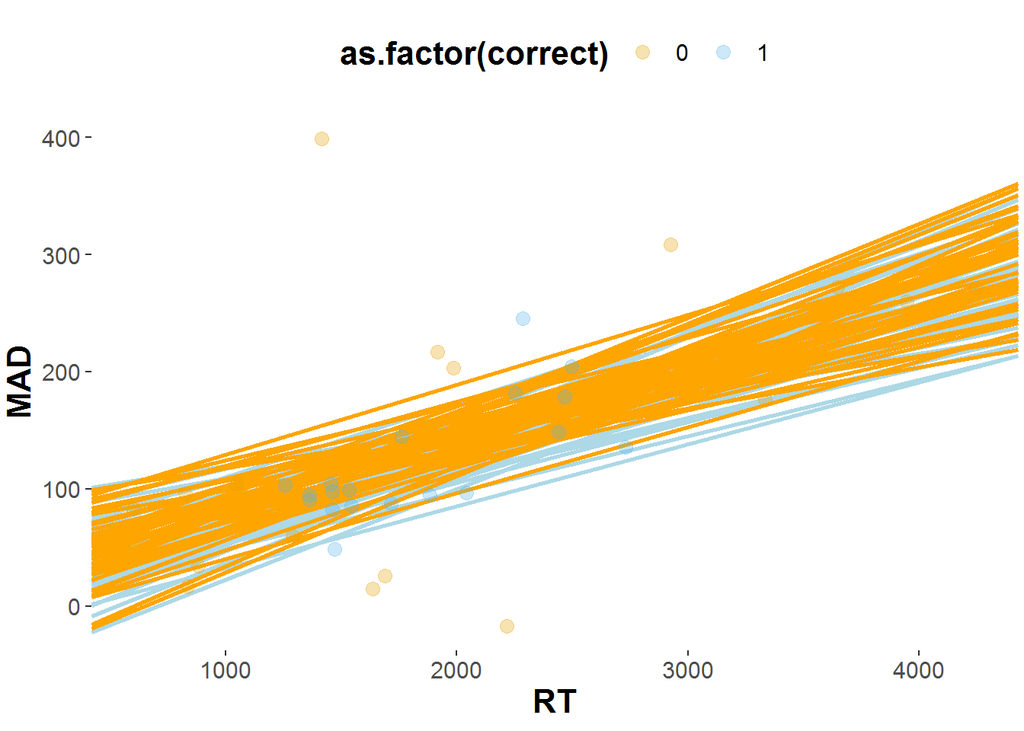

```r
# sample 100 random numbers from 4000 samples
random_50 <- sample(1:4000, 50, replace = FALSE)

# wrangle data frame
correct <- model1 %>%
  spread_draws(b_RT, b_Intercept, b_correct) %>%
  select(b_RT, b_Intercept, b_correct) %>%
  slice(random_50)



incorrect <- model1 %>%
  spread_draws(b_RT, b_Intercept) %>%
  select(b_RT, b_Intercept) %>%
  slice(random_50)

# plot
ggplot(data = df,
       aes(x = RT,
           y = MAD, color = as.factor(correct))) +
  geom_abline(data = correct,
              aes(intercept = b_Intercept+b_correct, slope = b_RT),
              color = "lightblue", size  = 1) +
  geom_abline(data = incorrect,
              aes(intercept = b_Intercept, slope = b_RT),
              color = "orange", size  = 1) +
  geom_point(size = 3, alpha = 0.3)+
  theme_aida()
```

6. BONUS II: Given our model and our data, calculate the evidential ratio of correct responses exhibiting larger MADs than incorrect responses.

```r
posteriors4 <- model1 %>%
  # use the spread_draws() function of tidybayes for all relevant parameters
  spread_draws(b_correct) %>%
  # select only those columns that are relevant
  select(b_correct) %>%
  # bring into long format
  gather(key = "parameter", value = "posterior")


posteriors4_agg <- posteriors4 %>%
  group_by(parameter) %>%
  summarise(mean_posterior = mean(posterior),
            `90lowerCrI` = HDInterval::hdi(posterior, credMass = 0.90)[1],
            `90higherCrI` = HDInterval::hdi(posterior, credMass = 0.90)[2])



hypothesis(model1, 'correct > -15')
```

```
## Hypothesis Tests for class b:
##            Hypothesis Estimate Est.Error CI.Lower CI.Upper Evid.Ratio
## 1 (correct)-(-15) > 0      0.6     26.54   -42.62    44.56       1.02
##   Post.Prob Star
## 1       0.5
## ---
## 'CI': 90%-CI for one-sided and 95%-CI for two-sided hypotheses.
## '*': For one-sided hypotheses, the posterior probability exceeds 95%;
## for two-sided hypotheses, the value tested against lies outside the 95%-CI.
## Posterior probabilities of point hypotheses assume equal prior probabilities.
```